# BULK RNA SEQUENCING

```python
import numpy as np
import pandas as pd
from scipy.stats import gamma, nbinom

# Setting seed for reproducibility
np.random.seed(42)

# Generating bulk RNA-seq dataset
num_genes = 5000
num_samples = 10

# Simulating counts for genes and samples using a gamma distribution
shape_param = 2  # Shape parameter for gamma distribution
scale_param = 100  # Scale parameter for gamma distribution

counts_data = np.random.gamma(shape_param, scale_param, size=(num_genes, num_samples)).astype(int)

# Assigning sample names and gene names
sample_names = [f"Sample_{i}" for i in range(1, num_samples + 1)]
gene_names = [f"Gene_{i}" for i in range(1, num_genes + 1)]

# Creating a DataFrame for counts
counts_df = pd.DataFrame(counts_data, index=gene_names, columns=sample_names)

# Display a portion of the counts DataFrame
print(counts_df.head(10))
```

```
         Sample_1  Sample_2  Sample_3  Sample_4  Sample_5  Sample_6  Sample_7  \
Gene_1        239       149       138       138       464       286       113
Gene_2         67       210       436       139       105       181       100
Gene_3        297        53        47       193       281       189       152
Gene_4        212       121        93       258       338       318        80
Gene_5        295       410       217        96       162       461       178
Gene_6         82       109       314       212       179       325        91
Gene_7         42       118       146       224       202       157        21
Gene_8        143       208       362       283       421        43        68
Gene_9         73       457        84       128       295        52        33
Gene_10       243       208        93       198       207        90       542

         Sample_8  Sample_9  Sample_10
Gene_1        246       199         21
Gene_2        131       164         64
Gene_3        130       113        343
Gene_4        129       112        143
Gene_5        130       139        217
Gene_6        127       207        202
Gene_7        163       174        729
Gene_8        103        35        175
Gene_9        191       202        289
Gene_10       235        69        290
```

```python
import pandas as pd
import numpy as np
from sklearn.decomposition import PCA
from sklearn.cluster import KMeans
import matplotlib.pyplot as plt
import seaborn as sns
```

```python
# Create a random dataset
data = pd.DataFrame(np.random.randint(1, 1000, size=(num_genes, num_samples)),
                    columns=[f"Sample_{i}" for i in range(1, num_samples + 1)],
                    index=[f"Gene_{i}" for i in range(1, num_genes + 1)])
```

```python
# Perform PCA for dimensionality reduction
pca = PCA(n_components=2)
pca_result = pca.fit_transform(data.T)  # Transpose data for samples as rows and genes as columns
```

```python
# Create a DataFrame with PCA results
pca_df = pd.DataFrame(data=pca_result, columns=['PC1', 'PC2'], index=data.columns)
```

# **PCA Visualization**

By visualizing samples in this reduced-dimensional space, the plot allows for the exploration of patterns, relationships, or separations between samples based on their distribution along the first and second principal components.

The x-axis represents PC1, and the y-axis represents PC2, which capture the highest variance within the data.

This visualization aids in understanding the overall structure or clustering tendencies present in the dataset.

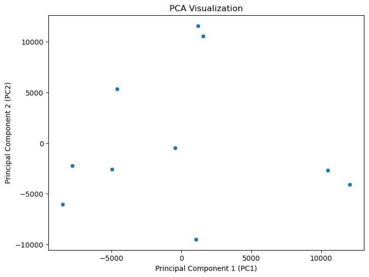

```python
# Visualize PCA results
plt.figure(figsize=(8, 6))
sns.scatterplot(x='PC1', y='PC2', data=pca_df)
plt.title('PCA Visualization')
plt.xlabel('Principal Component 1 (PC1)')
plt.ylabel('Principal Component 2 (PC2)')
plt.show()
```

```python
# Perform clustering using K-means
num_clusters = 3  # Number of clusters
kmeans = KMeans(n_clusters=num_clusters, random_state=42)
clusters = kmeans.fit_predict(data.T)
```

# **KMeans clustering visualization**

Each point in the plot represents a sample projected onto the two principal components (PC1 and PC2), with colors representing different clusters obtained from a clustering algorithm (that is, K-means).

The plot demonstrates the separation or grouping of samples based on their similarity in high-dimensional space, as represented by their positions in the lower-dimensional PCA space.

The legend displays different clusters, allowing for visual interpretation of sample groupings or clusters in a reduced-dimensional space.

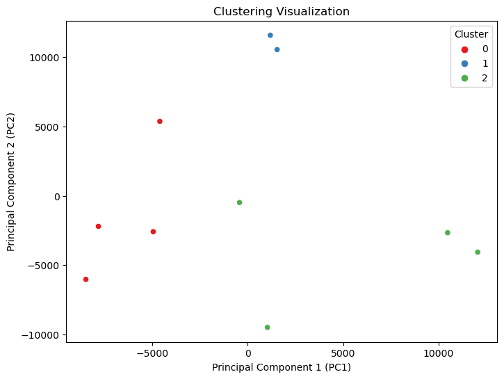

```python
# Visualize clustering results (using PCA for visualization)
plt.figure(figsize=(8, 6))
sns.scatterplot(x='PC1', y='PC2', data=pca_df, hue=clusters, palette='Set1', legend='full')
plt.title('Clustering Visualization')
plt.xlabel('Principal Component 1 (PC1)')
plt.ylabel('Principal Component 2 (PC2)')
plt.legend(title='Cluster')
plt.show()
```

# **Vocano plot**

A Volcano Plot is a concise visualization displaying log2 fold changes (x-axis) and -log10-transformed p-values (y-axis) for genes in two conditions.

Genes with significant changes and high significance appear further away from the center, with the threshold line indicating significance level.

The plots helps identify highly differentially expressed genes based on their magnitude of change and statistical significance.

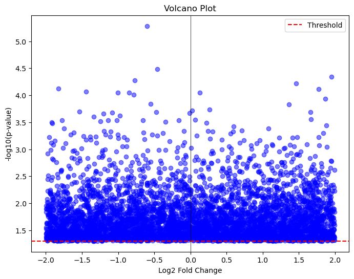

```python
# Having calculated differential expression between two conditions and have log2 fold change and p-values,
# We generate random log2 fold change and p-values for demonstration
log2_fold_change = np.random.uniform(low=-2, high=2, size=num_genes)
p_values = np.random.rand(num_genes) * 0.05  # Random p-values

# Volcano plot
plt.figure(figsize=(8, 6))
plt.scatter(log2_fold_change, -np.log10(p_values), color='blue', alpha=0.5)
plt.axhline(-np.log10(0.05), color='red', linestyle='--', label='Threshold')
plt.axvline(0, color='black', linestyle='-', linewidth=0.5)
plt.title('Volcano Plot')
plt.xlabel('Log2 Fold Change')
plt.ylabel('-log10(p-value)')
plt.legend()
plt.show()
```

# **Gene expression distribution**

This histogram visualizes the distribution of gene expression levels for a single sample (Sample_1).

It shows the frequency or count of genes at different expression levels within Sample_1. The bins represent ranges of expression values, and the KDE (Kernel Density Estimate) curve depicts the estimated probability density of the expression values

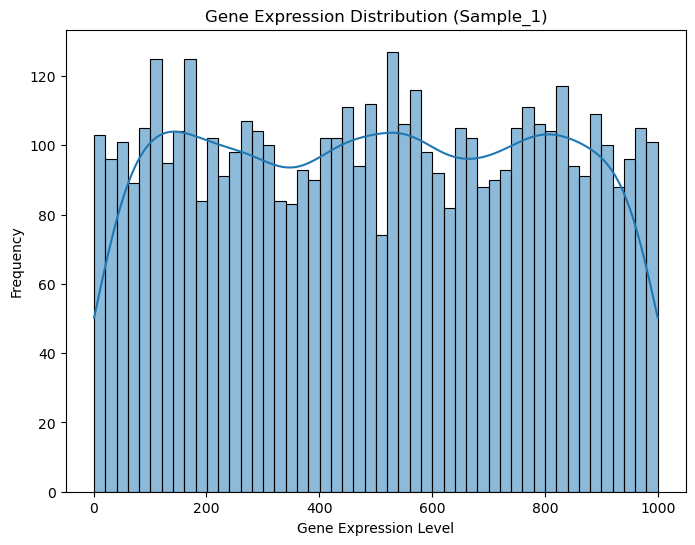

```python
# Histogram of gene expression for a single sample
plt.figure(figsize=(8, 6))
sns.histplot(data['Sample_1'], bins=50, kde=True)
plt.title('Gene Expression Distribution (Sample_1)')
plt.xlabel('Gene Expression Level')
plt.ylabel('Frequency')
plt.show()
```

# Gene expression of the samples

This box plot displays the distribution of gene expression levels across all samples

Each horizontal box represents the interquartile range (IQR) of gene expression for a specific sample.

The line inside the box represents the median expression level.

It allows for easy comparison of expression distributions between multiple samples

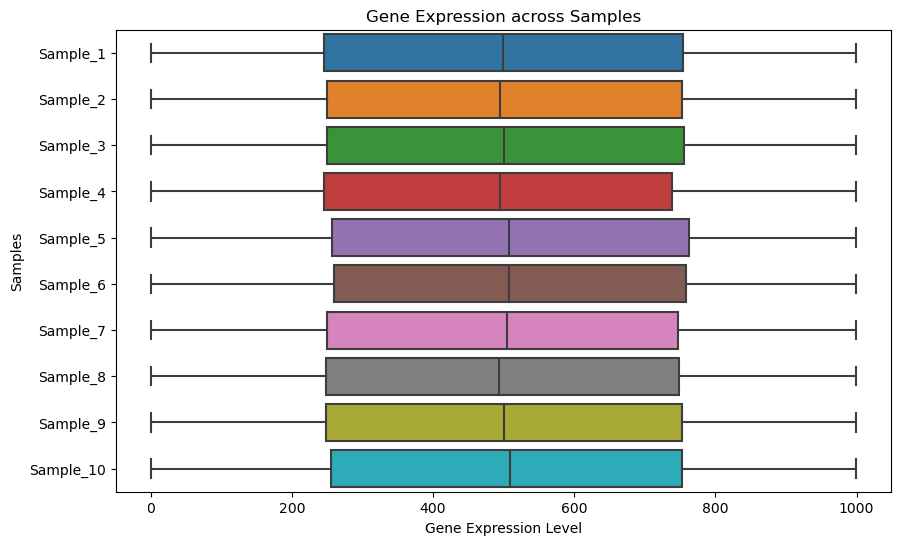

```python
# Box plot for gene expression across samples
plt.figure(figsize=(10, 6))
sns.boxplot(data=data, orient='h')
plt.title('Gene Expression across Samples')
plt.xlabel('Gene Expression Level')
plt.ylabel('Samples')
plt.show()
```

# **Gene expression heatmap**

Each cell in the heatmap represents the expression level of a gene in a specific sample.

The color intensity indicates the expression magnitude, allowing the visualization of expression patterns across all genes and samples.

Rows represent genes, while columns represent samples.

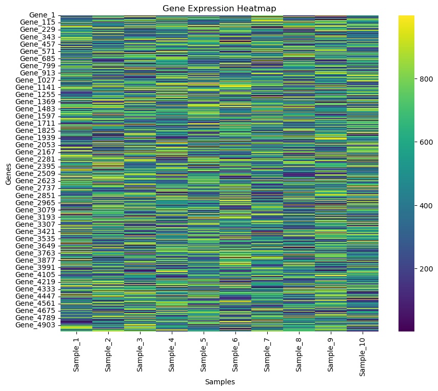

```python
# Heatmap visualization
plt.figure(figsize=(10, 8))
sns.heatmap(data, cmap='viridis')
plt.title('Gene Expression Heatmap')
plt.xlabel('Samples')
plt.ylabel('Genes')
plt.show()
```

# **Gene expression scatter plot**

Each point in the scatter plot represents a gene's expression level in Sample_1 (x-axis) versus Sample_2 (y-axis). The figure visualizes the correlation or relationship between the expression levels of genes across the two samples. A diagonal line or clustering indicates a strong correlation between the expression levels of genes in both samples.

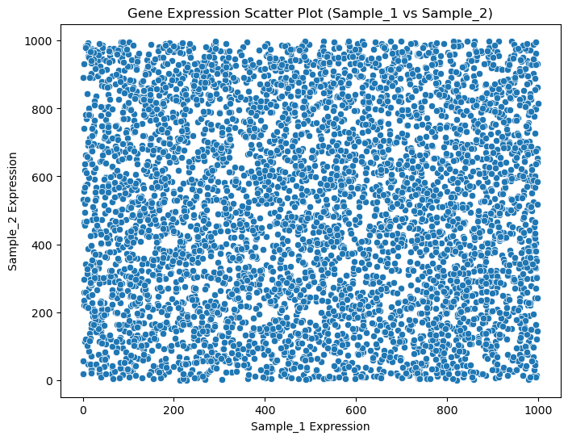

```python
# Scatter plot for two selected samples
plt.figure(figsize=(8, 6))
sns.scatterplot(x='Sample_1', y='Sample_2', data=data)
plt.title('Gene Expression Scatter Plot (Sample_1 vs Sample_2)')
plt.xlabel('Sample_1 Expression')
plt.ylabel('Sample_2 Expression')
plt.show()
```